# Reproducible Research Peer Assessment 1

Tayler Hentges

July 3, 2016

First set working directory to where data is located and read in data.

```r
setwd("C:/Users/ttop2/Desktop/repdata%2Fdata%2Factivity")
data<-read.csv("activity.csv")
summary(data)
```

```
##      steps                date          interval
##  Min.   :  0.00   2012-10-01:  288   Min.   :   0.0
##  1st Qu.:  0.00   2012-10-02:  288   1st Qu.: 588.8
##  Median :  0.00   2012-10-03:  288   Median :1177.5
##  Mean   : 37.38   2012-10-04:  288   Mean   :1177.5
##  3rd Qu.: 12.00   2012-10-05:  288   3rd Qu.:1766.2
##  Max.   :806.00   2012-10-06:  288   Max.   :2355.0
##  NA's   :2304     (Other)   :15840
```

Notice how there are many NAs in the document. Let’s remove those first.

```r
datanonas<-data[!is.na(data$steps),]
datanonas$date<-factor(datanonas$date)
summary(datanonas)
```

```
##      steps                date          interval
##  Min.   :  0.00   2012-10-02:  288   Min.   :   0.0
##  1st Qu.:  0.00   2012-10-03:  288   1st Qu.: 588.8
##  Median :  0.00   2012-10-04:  288   Median :1177.5
##  Mean   : 37.38   2012-10-05:  288   Mean   :1177.5
##  3rd Qu.: 12.00   2012-10-06:  288   3rd Qu.:1766.2
##  Max.   :806.00   2012-10-07:  288   Max.   :2355.0
##                   (Other)   :13536
```

One question we want to answer is the mean number of steps taken each day. First we will sum up the steps taken.

```r
dailysteps<-as.data.frame(tapply(datanonas$steps, as.factor(datanonas$date), sum))
names(dailysteps)<-c("Steps")
```

In order to visualize the data, a histogram will show the results of how many days have the specific number of steps.

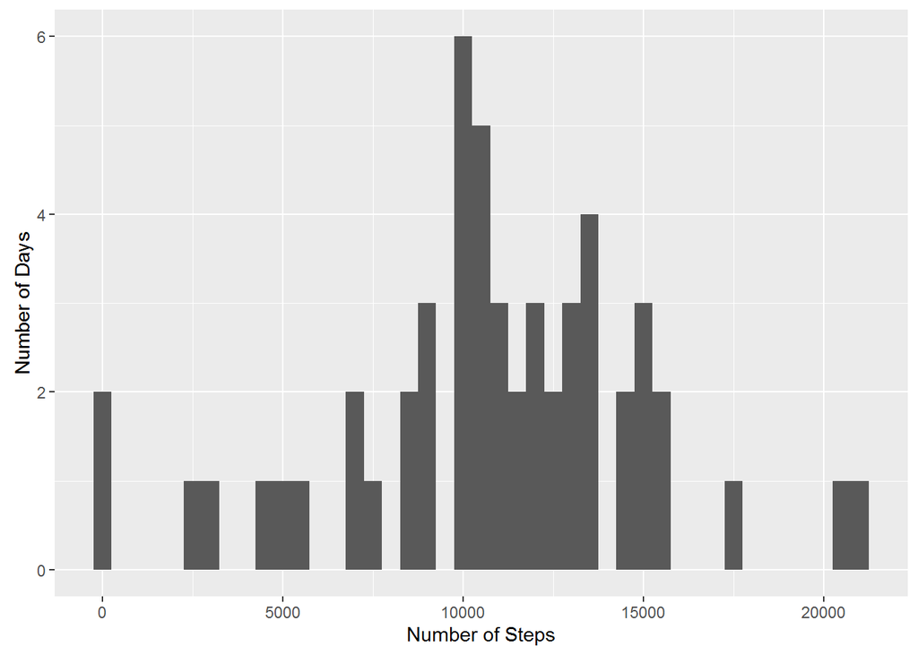

```r
library(ggplot2)
qplot(dailysteps$Steps, geom="histogram", ylab="Number of Days", xlab="Number of Steps", binwidth = 500)
```

For a more computational value, see the actual calculated values.

```r
print(mean(dailysteps$Steps), row.names = FALSE)
```

```
## [1] 10766.19
```

```r
print(median(dailysteps$Steps), row.names = FALSE)
```

```
## [1] 10765
```

The next question is what is the average daily activity? To calculate, we will look at the data by interval.

[figure not shown]

```r
stepsbyinterval<-tapply(datanonas$steps, as.factor(datanonas$interval), mean)
stepsbyinterval<-as.data.frame(stepsbyinterval)
stepsbyinterval$interval<-rownames(stepsbyinterval)
plot(stepsbyinterval$interval, stepsbyinterval$mean, type = 'l', ylab = "Mean of Steps", xlab = "Interval")
```

```r
colMax <- function(data) sapply(data, max, na.rm = TRUE)
colMax(stepsbyinterval)
```

```
##    stepsbyinterval           interval
## "206.169811320755"              "955"
```

Moving on, we want to improve the accuracy of some calculations by imputing the data. First let’s recall how many NAs are in the dataset.

```r
sum(is.na(data))
```

```
## [1] 2304
```

For simplicity, we will be changing the NAs to a mean at that point.

```r
stepsbyinterval$interval <- as.integer(stepsbyinterval$interval)
imputed <- merge(data, stepsbyinterval, by = "interval")
imputed$steps[is.na(imputed$steps)] <-imputed$stepsbyinterval[is.na(imputed$steps)]
summary(imputed)
```

```
##     interval          steps                date       stepsbyinterval
##  Min.   :   0.0   Min.   :  0.00   2012-10-01:  288   Min.   :  0.000
##  1st Qu.: 588.8   1st Qu.:  0.00   2012-10-02:  288   1st Qu.:  2.486
##  Median :1177.5   Median :  0.00   2012-10-03:  288   Median : 34.113
##  Mean   :1177.5   Mean   : 37.38   2012-10-04:  288   Mean   : 37.383
##  3rd Qu.:1766.2   3rd Qu.: 27.00   2012-10-05:  288   3rd Qu.: 52.835
##  Max.   :2355.0   Max.   :806.00   2012-10-06:  288   Max.   :206.170
##                                    (Other)   :15840
```

Next, lets create a histogram of the newly crafted data.

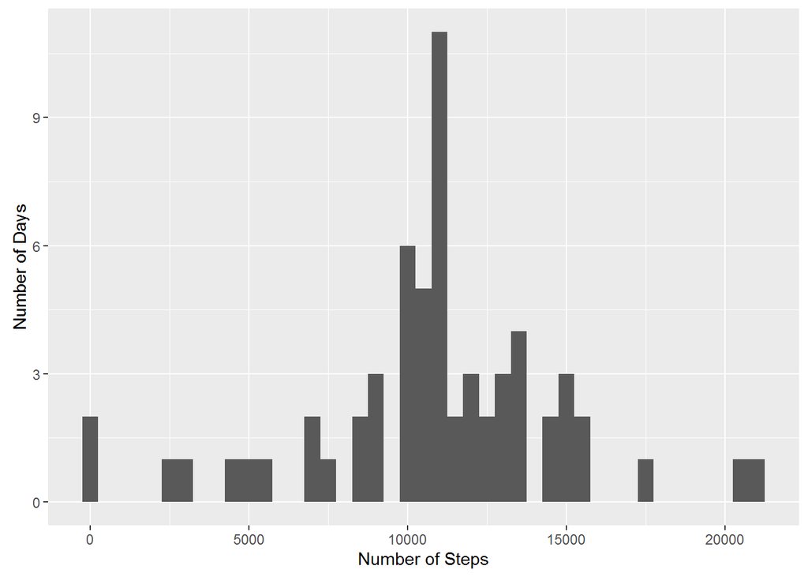

```r
imputedsums <- as.data.frame(tapply(imputed$steps, as.factor(imputed$date), sum))
names(imputedsums) <- c("Steps")
qplot(imputedsums$Steps, geom="histogram", ylab="Number of Days", xlab="Number of Steps", binwidth = 500)
```

And lastly let’s see how the means differ between the two sets.

```r
print(mean(imputedsums$Steps), row.names = FALSE)
```

```
## [1] 10766.19
```

```r
print(median(imputedsums$Steps), row.names = FALSE)
```

```
## [1] 10766.19
```

For our final question, we want to investigate to see if there is a difference in the number of steps between the weekdays and the weekend. To start, we must determine which days are weekdays/weekends and add this to the new dataset.

```r
imputed$dayofweek <- weekdays(as.Date(imputed$date))

wkday<- c('Monday', 'Tuesday', 'Wednesday', 'Thursday', 'Friday')

imputed$dtype <- factor(weekdays(as.Date(imputed$date)) %in% wkday,
                   levels=c(FALSE, TRUE), labels=c('weekend', 'weekday'))
head(imputed)
```

```
##   interval    steps       date stepsbyinterval dayofweek   dtype
## 1        0 1.716981 2012-10-01        1.716981    Monday weekday
## 2        0 0.000000 2012-11-23        1.716981    Friday weekday
## 3        0 0.000000 2012-10-28        1.716981    Sunday weekend
## 4        0 0.000000 2012-11-06        1.716981   Tuesday weekday
## 5        0 0.000000 2012-11-24        1.716981  Saturday weekend
## 6        0 0.000000 2012-11-15        1.716981  Thursday weekday
```

And now our final calculation to determine if there is a difference.

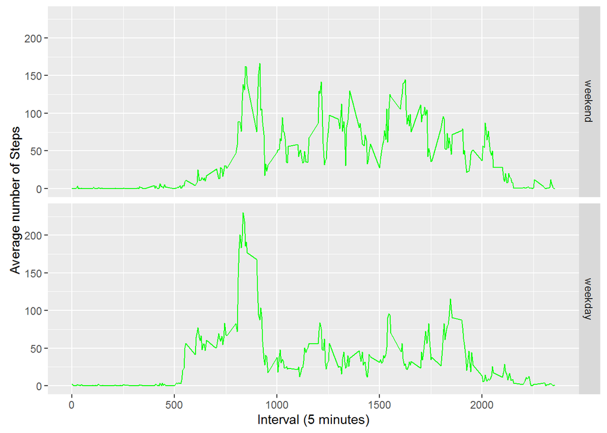

```r
averages <- aggregate(steps ~ interval + dtype, data=imputed, mean)
ggplot(averages, aes(interval, steps)) + geom_line(colour="green") + facet_grid(dtype ~ .) +
  xlab("Interval (5 minutes)") + ylab("Average number of Steps")
```